# Finalisation de la base de travail

# 1. Import de la base de travail et ajout annee de pose

Import de la derniere base :

```r
TAB_bis <- read.table("TAB_bis.csv",sep=";",header=T)
names(TAB_bis)
```

```
##  [1] "ID_DEFAUT"         "LIGNE"             "VOIE_bis"
##  [4] "METRE"             "Profil"            "VITESSE"
##  [7] "TYPE_CLASSEMENT"   "EMPLACEMENT"       "AGE"
## [10] "RANG"              "AGE_bis"           "VITESSE_bis"
## [13] "TYPE_RAYON_COURBE" "TRAIN"             "UIC"
## [16] "Class_Binaire"
```

=> 11767 obs et 16 variables

Ajout de la variable annee de pose :

```r
DEF_PN_BIS <- read.table("DEF_PN_BIS.csv",sep=";",header=T)
DEF_PN_TER <- DEF_PN_BIS[,c(3,6)]
BASE_TRAVAIL <- merge(TAB_bis,DEF_PN_TER,by="ID_DEFAUT",all.x = TRUE)
names(BASE_TRAVAIL)
```

```
##  [1] "ID_DEFAUT"         "LIGNE"             "VOIE_bis"
##  [4] "METRE"             "Profil"            "VITESSE"
##  [7] "TYPE_CLASSEMENT"   "EMPLACEMENT"       "AGE"
## [10] "RANG"              "AGE_bis"           "VITESSE_bis"
## [13] "TYPE_RAYON_COURBE" "TRAIN"             "UIC"
## [16] "Class_Binaire"     "ANNEE_POSE"
```

Inspection de la base :

```r
str(BASE_TRAVAIL)
```

```
## 'data.frame':    11767 obs. of  17 variables:
##  $ ID_DEFAUT        : int  14378 14491 14610 14839 14898 310270 310275 310280 310281 310301 ...
##  $ LIGNE            : int  990000 990000 990000 990000 990000 272000 1306 272000 272000 272000 ...
##  $ VOIE_bis         : Factor w/ 111 levels "10","11","12",..: 71 65 65 65 65 92 64 6 53 84 ...
##  $ METRE            : int  61421 60180 61280 61180 61575 1190 300 260 2200 2040 ...
##  $ Profil           : Factor w/ 5 levels "46-E2","50-E6",..: 2 2 2 2 4 4 2 2 2 4 ...
##  $ VITESSE          : int  70 70 70 70 70 60 30 60 30 90 ...
##  $ TYPE_CLASSEMENT  : Factor w/ 6 levels "E","NR","O","S",..: 3 3 3 5 5 3 3 3 3 3 ...
##  $ EMPLACEMENT      : Factor w/ 3 levels "","Ciel ouvert",..: 2 2 2 2 2 2 2 2 2 2 ...
##  $ AGE              : int  27 29 30 29 30 14 37 14 15 22 ...
##  $ RANG             : int  2 2 2 2 2 1 2 1 1 1 ...
##  $ AGE_bis          : Factor w/ 11 levels "(-20,0]","(0,10]",..: 4 4 4 4 4 3 5 3 3 4 ...
##  $ VITESSE_bis      : Factor w/ 6 levels "(-10,0]","(0,50]",..: 6 6 6 6 6 6 2 6 2 6 ...
##  $ TYPE_RAYON_COURBE: Factor w/ 2 levels "ALIGNEMENT","COURBE": 2 1 1 1 2 1 1 1 1 2 ...
##  $ TRAIN            : Factor w/ 3 levels "Autre","TGV",..: NA NA NA NA NA 3 1 1 1 3 ...
##  $ UIC              : Factor w/ 3 levels "G2_4","G5_6",..: 1 1 1 1 1 2 2 2 2 1 ...
##  $ Class_Binaire    : int  0 0 0 1 1 0 0 0 0 0 ...
##  $ ANNEE_POSE       : int  1979 1977 1977 1977 1977 1993 1963 1993 1993 1981 ...
```

```r
summary(BASE_TRAVAIL)
```

```
##    ID_DEFAUT           LIGNE           VOIE_bis        METRE
##  Min.   :  14378   Min.   :  1306   V1     :4235   Min.   :     2
##  1st Qu.: 326500   1st Qu.:229000   V2     :3774   1st Qu.: 18767
##  Median :2502484   Median :272000   V1BIS  :1047   Median : 29366
##  Mean   :1922609   Mean   :280033   V2BIS  : 818   Mean   : 39768
##  3rd Qu.:2802341   3rd Qu.:272000   UNIQUE : 578   3rd Qu.: 57378
##  Max.   :3038632   Max.   :992300   V2L    : 108   Max.   :116175
##                                     (Other):1207
##    Profil        VITESSE    TYPE_CLASSEMENT      EMPLACEMENT
##  46-E2:1124   Min.   :  0   E :   2                    : 1404
##  50-E6:4451   1st Qu.:100   NR:   1         Ciel ouvert:10356
##  55-E1:   4   Median :120   O :7860         Tunnel     :    7
##  60-E1:5824   Mean   :123   S :   2
##  Autre: 176   3rd Qu.:160   X1:3491
##  NA's : 188   Max.   :300   X2: 411
##
##       AGE              RANG         AGE_bis        VITESSE_bis
##  Min.   :  0.00   Min.   :1.00   (20,30]:4771   (-10,0]  :  32
##  1st Qu.: 21.00   1st Qu.:1.00   (30,40]:2326   (0,50]   : 485
##  Median : 26.00   Median :1.00   (10,20]:1976   (100,160]:7629
##  Mean   : 29.82   Mean   :1.02   (40,50]:1135   (160,200]: 642
##  3rd Qu.: 36.00   3rd Qu.:1.00   (50,60]: 554   (200,400]:   4
##  Max.   :116.00   Max.   :2.00   (Other): 981   (50,100] :2975
##                                  NA's   :  24
##   TYPE_RAYON_COURBE        TRAIN        UIC       Class_Binaire
##  ALIGNEMENT:9648    Autre     :4214   G2_4:8089   Min.   :0.0000
##  COURBE    :2119    TGV       : 435   G5_6:2627   1st Qu.:0.0000
##                     TRANSILIEN:7092   G7_9:1051   Median :0.0000
##                     NA's      :  26               Mean   :0.3318
##                                                   3rd Qu.:1.0000
##                                                   Max.   :1.0000
##
##    ANNEE_POSE
##  Min.   :1900
##  1st Qu.:1974
##  Median :1984
##  Mean   :1982
##  3rd Qu.:1993
##  Max.   :2016
##  NA's   :24
```

# 2. Verification et Gestion des NA :

```r
# Class_Binaire et TYPE_CLASSEMENT
table(BASE_TRAVAIL$Class_Binaire, BASE_TRAVAIL$TYPE_CLASSEMENT, useNA="always")
```

```
##
##           E   NR    O    S   X1   X2 <NA>
##   0       2    1 7860    0    0    0    0
##   1       0    0    0    2 3491  411    0
##   <NA>    0    0    0    0    0    0    0
```

```r
# TYPE_RAYON_COURBE
table(BASE_TRAVAIL$TYPE_RAYON_COURBE, useNA="always")
```

```
##
## ALIGNEMENT     COURBE       <NA>
##       9648       2119          0
```

```r
# ANNEE_POSE
table(BASE_TRAVAIL$ANNEE_POSE, useNA="always") # 24 NA : On les supprime
```

```
##
## 1900 1903 1908 1912 1914 1922 1924 1925 1926 1928 1930 1932 1934 1936 1937
##    3    8    2    4   17  117    8   18   27   10    7    7   15   37   42
## 1938 1939 1940 1941 1943 1946 1947 1949 1950 1951 1952 1954 1955 1957 1958
##   10    2    7    4    1    7    2   15  124    8    5  182   31    3  124
## 1959 1960 1961 1962 1963 1964 1965 1966 1967 1968 1969 1970 1971 1972 1973
##  177   82  106   87  136   63    9   12   25   57  511   39   87   92  399
## 1974 1975 1976 1977 1978 1979 1980 1981 1982 1983 1984 1985 1986 1987 1988
##  231  396  247  329   34  251  277  292  186  249  661  357   96  291    7
## 1989 1990 1991 1992 1993 1994 1995 1996 1997 1998 1999 2000 2001 2002 2003
##  971  299   59  770  459 1545   20  114   25   47   74   48    5  207   14
## 2004 2005 2006 2007 2008 2009 2010 2011 2012 2013 2014 2015 2016 <NA>
##    2    7    1   95   41   50   11   13   41  134   43    1   14   24
```

```r
BASE_TRAVAIL <- BASE_TRAVAIL[complete.cases(BASE_TRAVAIL$ANNEE_POSE),]
table(BASE_TRAVAIL$ANNEE_POSE, useNA="always")
```

```
##
## 1900 1903 1908 1912 1914 1922 1924 1925 1926 1928 1930 1932 1934 1936 1937
##    3    8    2    4   17  117    8   18   27   10    7    7   15   37   42
## 1938 1939 1940 1941 1943 1946 1947 1949 1950 1951 1952 1954 1955 1957 1958
##   10    2    7    4    1    7    2   15  124    8    5  182   31    3  124
## 1959 1960 1961 1962 1963 1964 1965 1966 1967 1968 1969 1970 1971 1972 1973
##  177   82  106   87  136   63    9   12   25   57  511   39   87   92  399
## 1974 1975 1976 1977 1978 1979 1980 1981 1982 1983 1984 1985 1986 1987 1988
##  231  396  247  329   34  251  277  292  186  249  661  357   96  291    7
## 1989 1990 1991 1992 1993 1994 1995 1996 1997 1998 1999 2000 2001 2002 2003
##  971  299   59  770  459 1545   20  114   25   47   74   48    5  207   14
## 2004 2005 2006 2007 2008 2009 2010 2011 2012 2013 2014 2015 2016 <NA>
##    2    7    1   95   41   50   11   13   41  134   43    1   14    0
```

```r
# Création de tranches :
BASE_TRAVAIL$TR_ANNEE_POSE <- "Apres 2000"
BASE_TRAVAIL$TR_ANNEE_POSE[BASE_TRAVAIL$ANNEE_POSE<=2000] <- "]1990;2000]"
BASE_TRAVAIL$TR_ANNEE_POSE[BASE_TRAVAIL$ANNEE_POSE<=1990] <- "]1980;1990]"
BASE_TRAVAIL$TR_ANNEE_POSE[BASE_TRAVAIL$ANNEE_POSE<=1980] <- "]1970;1980]"
BASE_TRAVAIL$TR_ANNEE_POSE[BASE_TRAVAIL$ANNEE_POSE<=1970] <- "Avant 1970"
# puis on retransforme en facteur :
BASE_TRAVAIL$TR_ANNEE_POSE<-factor(BASE_TRAVAIL$TR_ANNEE_POSE)
table(BASE_TRAVAIL$TR_ANNEE_POSE, useNA="always")
```

```
##
## ]1970;1980] ]1980;1990] ]1990;2000]  Apres 2000  Avant 1970        <NA>
##        2343        3409        3161         679        2151           0
```

```r
BASE_TRAVAIL$TR_ANNEE_POSE<-relevel(BASE_TRAVAIL$TR_ANNEE_POSE,ref="Avant 1970")
table(BASE_TRAVAIL$TR_ANNEE_POSE, useNA="always")
```

```
##
##  Avant 1970 ]1970;1980] ]1980;1990] ]1990;2000]  Apres 2000        <NA>
##        2151        2343        3409        3161         679           0
```

```r
# AGE et AGE_BIS :
table(BASE_TRAVAIL$AGE_bis, useNA="always")
```

```
##
##  (-20,0]   (0,10]  (10,20]  (20,30]  (30,40]  (40,50]  (50,60]  (60,70]
##      109      440     1976     4771     2326     1135      554      135
##  (70,80]  (80,90] (90,200]     <NA>
##       96      135       66        0
```

```r
table(BASE_TRAVAIL$AGE, useNA="always")
```

```
##
##    0    1    2    3    4    5    6    7    8    9   10   11   12   13   14
##   60   19   52   87   60   39   36   47   30   32   38   24   60  108  183
##   15   16   17   18   19   20   21   22   23   24   25   26   27   28   29
##  228  170  316  269  332  296  748  656  859  425  428  437  364  398  304
##   30   31   32   33   34   35   36   37   38   39   40   41   42   43   44
##  167  287  333  280  250  217  240  163  217  176  172  179  119  125   95
##   45   46   47   48   49   50   51   52   53   54   55   56   57   58   59
##   69  120  216   92   66   67   47   83   70   80   63   38   71   76   23
##   60   61   62   63   64   65   66   67   68   69   70   71   72   73   74
##    5    2   29    8   22   23   11   11    9    8   12    8   11    3    7
##   75   76   77   78   79   80   81   82   83   84   85   86   87   88   89
##    9    8    9    9   12   20   17   28   12   23   10   23    4    1    6
##   90   91   92   93   94   95   98   99  101  102  110  111  114  115  116
##   11    2   20    6   15    1    1    4    1    5    1    6    1    2    1
## <NA>
##    0
```

```r
table(BASE_TRAVAIL$AGE_bis , BASE_TRAVAIL$AGE , useNA="always")
```

```
##
##              0   1   2   3   4   5   6   7   8   9  10  11  12  13  14  15
##   (-20,0]   60   0   0   0   0   0   0   0   0   0   0   1   1   1   1   0
##   (0,10]     0  19  52  87  60  39  36  47  30  32  38   0   0   0   0   0
##   (10,20]    0   0   0   0   0   0   0   0   0   0   0  23  59 107 182 228
##   (20,30]    0   0   0   0   0   0   0   0   0   0   0   0   0   0   0   0
##   (30,40]    0   0   0   0   0   0   0   0   0   0   0   0   0   0   0   0
##   (40,50]    0   0   0   0   0   0   0   0   0   0   0   0   0   0   0   0
##   (50,60]    0   0   0   0   0   0   0   0   0   0   0   0   0   0   0   0
##   (60,70]    0   0   0   0   0   0   0   0   0   0   0   0   0   0   0   0
##   (70,80]    0   0   0   0   0   0   0   0   0   0   0   0   0   0   0   0
##   (80,90]    0   0   0   0   0   0   0   0   0   0   0   0   0   0   0   0
##   (90,200]   0   0   0   0   0   0   0   0   0   0   0   0   0   0   0   0
##   <NA>       0   0   0   0   0   0   0   0   0   0   0   0   0   0   0   0
##
##             16  17  18  19  20  21  22  23  24  25  26  27  28  29  30  31
##   (-20,0]    1   1   4   0   0   0   1   1   0   4   0   2   6   0   1   3
##   (0,10]     0   0   0   0   0   0   0   0   0   0   0   0   0   0   0   0
##   (10,20]  169 315 265 332 296   0   0   0   0   0   0   0   0   0   0   0
##   (20,30]    0   0   0   0   0 748 655 858 425 424 437 362 392 304 166   0
##   (30,40]    0   0   0   0   0   0   0   0   0   0   0   0   0   0   0 284
##   (40,50]    0   0   0   0   0   0   0   0   0   0   0   0   0   0   0   0
##   (50,60]    0   0   0   0   0   0   0   0   0   0   0   0   0   0   0   0
##   (60,70]    0   0   0   0   0   0   0   0   0   0   0   0   0   0   0   0
##   (70,80]    0   0   0   0   0   0   0   0   0   0   0   0   0   0   0   0
##   (80,90]    0   0   0   0   0   0   0   0   0   0   0   0   0   0   0   0
##   (90,200]   0   0   0   0   0   0   0   0   0   0   0   0   0   0   0   0
##   <NA>       0   0   0   0   0   0   0   0   0   0   0   0   0   0   0   0
##
##             32  33  34  35  36  37  38  39  40  41  42  43  44  45  46  47
##   (-20,0]    1   2   0   2   0   1   0   0   0   5   0   0   0   0   4   1
##   (0,10]     0   0   0   0   0   0   0   0   0   0   0   0   0   0   0   0
##   (10,20]    0   0   0   0   0   0   0   0   0   0   0   0   0   0   0   0
##   (20,30]    0   0   0   0   0   0   0   0   0   0   0   0   0   0   0   0
##   (30,40]  332 278 250 215 240 162 217 176 172   0   0   0   0   0   0   0
##   (40,50]    0   0   0   0   0   0   0   0   0 174 119 125  95  69 116 215
##   (50,60]    0   0   0   0   0   0   0   0   0   0   0   0   0   0   0   0
##   (60,70]    0   0   0   0   0   0   0   0   0   0   0   0   0   0   0   0
##   (70,80]    0   0   0   0   0   0   0   0   0   0   0   0   0   0   0   0
##   (80,90]    0   0   0   0   0   0   0   0   0   0   0   0   0   0   0   0
```

[output cut: 43 more lines]

```
##   <NA>       0   0   0   0   0   0   0   0   0   0   0   0   0   0   0   0
##
##             98  99 101 102 110 111 114 115 116 <NA>
##   (-20,0]    0   0   0   0   0   0   0   0   0    0
##   (0,10]     0   0   0   0   0   0   0   0   0    0
##   (10,20]    0   0   0   0   0   0   0   0   0    0
##   (20,30]    0   0   0   0   0   0   0   0   0    0
##   (30,40]    0   0   0   0   0   0   0   0   0    0
##   (40,50]    0   0   0   0   0   0   0   0   0    0
##   (50,60]    0   0   0   0   0   0   0   0   0    0
##   (60,70]    0   0   0   0   0   0   0   0   0    0
##   (70,80]    0   0   0   0   0   0   0   0   0    0
##   (80,90]    0   0   0   0   0   0   0   0   0    0
##   (90,200]   1   4   1   5   1   6   1   2   1    0
##   <NA>       0   0   0   0   0   0   0   0   0    0
```

```r
# incoherence => on relance le code :
BASE_TRAVAIL$AGE_bis<-cut(BASE_TRAVAIL$AGE,breaks = c(0,10,20,30,40,50,60,70,80,90,200))
table(BASE_TRAVAIL$AGE_bis, useNA="always") # il reste les 60 age=0 à NA
```

```
##
##   (0,10]  (10,20]  (20,30]  (30,40]  (40,50]  (50,60]  (60,70]  (70,80]
##      440     1986     4786     2335     1148      556      135       96
##  (80,90] (90,200]     <NA>
##      135       66       60
```

```r
# Puis on modifie 0 et (0,10] en [0,10]. Mais comme c'est un facteur il faut d'abord le transformer en caracteres :
BASE_TRAVAIL$AGE_bis <- as.character( BASE_TRAVAIL$AGE_bis)
str(BASE_TRAVAIL)
```

```
## 'data.frame':    11743 obs. of  18 variables:
##  $ ID_DEFAUT        : int  14378 14491 14610 14839 14898 310270 310275 310280 310281 310301 ...
##  $ LIGNE            : int  990000 990000 990000 990000 990000 272000 1306 272000 272000 272000 ...
##  $ VOIE_bis         : Factor w/ 111 levels "10","11","12",..: 71 65 65 65 65 92 64 6 53 84 ...
##  $ METRE            : int  61421 60180 61280 61180 61575 1190 300 260 2200 2040 ...
##  $ Profil           : Factor w/ 5 levels "46-E2","50-E6",..: 2 2 2 2 4 4 2 2 2 4 ...
##  $ VITESSE          : int  70 70 70 70 70 60 30 60 30 90 ...
##  $ TYPE_CLASSEMENT  : Factor w/ 6 levels "E","NR","O","S",..: 3 3 3 5 5 3 3 3 3 3 ...
##  $ EMPLACEMENT      : Factor w/ 3 levels "","Ciel ouvert",..: 2 2 2 2 2 2 2 2 2 2 ...
##  $ AGE              : int  27 29 30 29 30 14 37 14 15 22 ...
##  $ RANG             : int  2 2 2 2 2 1 2 1 1 1 ...
##  $ AGE_bis          : chr  "(20,30]" "(20,30]" "(20,30]" "(20,30]" ...
##  $ VITESSE_bis      : Factor w/ 6 levels "(-10,0]","(0,50]",..: 6 6 6 6 6 6 2 6 2 6 ...
##  $ TYPE_RAYON_COURBE: Factor w/ 2 levels "ALIGNEMENT","COURBE": 2 1 1 1 2 1 1 1 1 2 ...
##  $ TRAIN            : Factor w/ 3 levels "Autre","TGV",..: NA NA NA NA NA 3 1 1 1 3 ...
##  $ UIC              : Factor w/ 3 levels "G2_4","G5_6",..: 1 1 1 1 1 2 2 2 2 1 ...
##  $ Class_Binaire    : int  0 0 0 1 1 0 0 0 0 0 ...
##  $ ANNEE_POSE       : int  1979 1977 1977 1977 1977 1993 1963 1993 1993 1981 ...
##  $ TR_ANNEE_POSE    : Factor w/ 5 levels "Avant 1970","]1970;1980]",..: 2 2 2 2 2 4 1 4 4 3 ...
```

```r
BASE_TRAVAIL$AGE_bis[is.na(BASE_TRAVAIL$AGE_bis)]   <- "[0,10]"
BASE_TRAVAIL$AGE_bis[BASE_TRAVAIL$AGE_bis=="(0,10]"]<-"[0,10]"
table(BASE_TRAVAIL$AGE_bis, useNA="always")
```

```
##
##  (10,20]  (20,30]  (30,40]  (40,50]  (50,60]  (60,70]  (70,80]  (80,90]
##     1986     4786     2335     1148      556      135       96      135
## (90,200]   [0,10]     <NA>
##       66      500        0
```

```r
# puis on retransforme en facteur :
BASE_TRAVAIL$AGE_bis<-factor(BASE_TRAVAIL$AGE_bis)
BASE_TRAVAIL$AGE_bis<-relevel(BASE_TRAVAIL$AGE_bis,ref="[0,10]")
table(BASE_TRAVAIL$AGE_bis, useNA="always")
```

```
##
##   [0,10]  (10,20]  (20,30]  (30,40]  (40,50]  (50,60]  (60,70]  (70,80]
##      500     1986     4786     2335     1148      556      135       96
##  (80,90] (90,200]     <NA>
##      135       66        0
```

```r
# VITESSE et VITESSE_bis :
table(BASE_TRAVAIL$VITESSE_bis, useNA="always")
```

```
##
##   (-10,0]    (0,50] (100,160] (160,200] (200,400]  (50,100]      <NA>
##        15       485      7625       642         4      2972         0
```

```r
table(BASE_TRAVAIL$VITESSE, useNA="always")
```

```
##
##    0   30   40   60   70   80   90  100  110  120  130  140  150  160  200
##   15  420   65  282   43  144  681 1822 1959 1356  505 1200  184 2421  642
##  300 <NA>
##    4    0
```

```r
table(BASE_TRAVAIL$VITESSE_bis , BASE_TRAVAIL$VITESSE , useNA="always")
```

```
##
##                0   30   40   60   70   80   90  100  110  120  130  140
##   (-10,0]     15    0    0    0    0    0    0    0    0    0    0    0
##   (0,50]       0  420   65    0    0    0    0    0    0    0    0    0
##   (100,160]    0    0    0    0    0    0    0    0 1959 1356  505 1200
##   (160,200]    0    0    0    0    0    0    0    0    0    0    0    0
##   (200,400]    0    0    0    0    0    0    0    0    0    0    0    0
##   (50,100]     0    0    0  282   43  144  681 1822    0    0    0    0
##   <NA>         0    0    0    0    0    0    0    0    0    0    0    0
##
##              150  160  200  300 <NA>
##   (-10,0]      0    0    0    0    0
##   (0,50]       0    0    0    0    0
##   (100,160]  184 2421    0    0    0
##   (160,200]    0    0  642    0    0
##   (200,400]    0    0    0    4    0
##   (50,100]     0    0    0    0    0
##   <NA>         0    0    0    0    0
```

```r
# On met la categorie (-10,0] qui correspond à 15 vitesse=0 dans (0,50]. Mais comme c'est un facteur il faut d'abord le transformer en caracteres :
BASE_TRAVAIL$VITESSE_bis <- as.character( BASE_TRAVAIL$VITESSE_bis)
str(BASE_TRAVAIL)
```

```
## 'data.frame':    11743 obs. of  18 variables:
##  $ ID_DEFAUT        : int  14378 14491 14610 14839 14898 310270 310275 310280 310281 310301 ...
##  $ LIGNE            : int  990000 990000 990000 990000 990000 272000 1306 272000 272000 272000 ...
##  $ VOIE_bis         : Factor w/ 111 levels "10","11","12",..: 71 65 65 65 65 92 64 6 53 84 ...
##  $ METRE            : int  61421 60180 61280 61180 61575 1190 300 260 2200 2040 ...
##  $ Profil           : Factor w/ 5 levels "46-E2","50-E6",..: 2 2 2 2 4 4 2 2 2 4 ...
##  $ VITESSE          : int  70 70 70 70 70 60 30 60 30 90 ...
##  $ TYPE_CLASSEMENT  : Factor w/ 6 levels "E","NR","O","S",..: 3 3 3 5 5 3 3 3 3 3 ...
##  $ EMPLACEMENT      : Factor w/ 3 levels "","Ciel ouvert",..: 2 2 2 2 2 2 2 2 2 2 ...
##  $ AGE              : int  27 29 30 29 30 14 37 14 15 22 ...
##  $ RANG             : int  2 2 2 2 2 1 2 1 1 1 ...
##  $ AGE_bis          : Factor w/ 10 levels "[0,10]","(10,20]",..: 3 3 3 3 3 2 4 2 2 3 ...
##  $ VITESSE_bis      : chr  "(50,100]" "(50,100]" "(50,100]" "(50,100]" ...
##  $ TYPE_RAYON_COURBE: Factor w/ 2 levels "ALIGNEMENT","COURBE": 2 1 1 1 2 1 1 1 1 2 ...
##  $ TRAIN            : Factor w/ 3 levels "Autre","TGV",..: NA NA NA NA NA 3 1 1 1 3 ...
##  $ UIC              : Factor w/ 3 levels "G2_4","G5_6",..: 1 1 1 1 1 2 2 2 2 1 ...
##  $ Class_Binaire    : int  0 0 0 1 1 0 0 0 0 0 ...
##  $ ANNEE_POSE       : int  1979 1977 1977 1977 1977 1993 1963 1993 1993 1981 ...
##  $ TR_ANNEE_POSE    : Factor w/ 5 levels "Avant 1970","]1970;1980]",..: 2 2 2 2 2 4 1 4 4 3 ...
```

```r
BASE_TRAVAIL$VITESSE_bis[BASE_TRAVAIL$VITESSE_bis=="(-10,0]"]<-"[0,50]"
BASE_TRAVAIL$VITESSE_bis[BASE_TRAVAIL$VITESSE_bis=="(0,50]"]<-"[0,50]"
table(BASE_TRAVAIL$VITESSE_bis, useNA="always")
```

```
##
## (100,160] (160,200] (200,400]  (50,100]    [0,50]      <NA>
##      7625       642         4      2972       500         0
```

```r
# puis on retransforme en facteur et on range les valeurs :
BASE_TRAVAIL$VITESSE_bis<-factor(BASE_TRAVAIL$VITESSE_bis)
BASE_TRAVAIL$VITESSE_bis<-factor(BASE_TRAVAIL$VITESSE_bis,c("[0,50]","(50,100]","(100,160]","(160,200]","(200,400]"))
table(BASE_TRAVAIL$VITESSE_bis, useNA="always")
```

```
##
##    [0,50]  (50,100] (100,160] (160,200] (200,400]      <NA>
##       500      2972      7625       642         4         0
```

```r
# UIC: codage des modalités pour comprehension :
str(BASE_TRAVAIL)
```

```
## 'data.frame':    11743 obs. of  18 variables:
##  $ ID_DEFAUT        : int  14378 14491 14610 14839 14898 310270 310275 310280 310281 310301 ...
##  $ LIGNE            : int  990000 990000 990000 990000 990000 272000 1306 272000 272000 272000 ...
##  $ VOIE_bis         : Factor w/ 111 levels "10","11","12",..: 71 65 65 65 65 92 64 6 53 84 ...
##  $ METRE            : int  61421 60180 61280 61180 61575 1190 300 260 2200 2040 ...
##  $ Profil           : Factor w/ 5 levels "46-E2","50-E6",..: 2 2 2 2 4 4 2 2 2 4 ...
##  $ VITESSE          : int  70 70 70 70 70 60 30 60 30 90 ...
##  $ TYPE_CLASSEMENT  : Factor w/ 6 levels "E","NR","O","S",..: 3 3 3 5 5 3 3 3 3 3 ...
##  $ EMPLACEMENT      : Factor w/ 3 levels "","Ciel ouvert",..: 2 2 2 2 2 2 2 2 2 2 ...
##  $ AGE              : int  27 29 30 29 30 14 37 14 15 22 ...
##  $ RANG             : int  2 2 2 2 2 1 2 1 1 1 ...
##  $ AGE_bis          : Factor w/ 10 levels "[0,10]","(10,20]",..: 3 3 3 3 3 2 4 2 2 3 ...
##  $ VITESSE_bis      : Factor w/ 5 levels "[0,50]","(50,100]",..: 2 2 2 2 2 2 1 2 1 2 ...
##  $ TYPE_RAYON_COURBE: Factor w/ 2 levels "ALIGNEMENT","COURBE": 2 1 1 1 2 1 1 1 1 2 ...
##  $ TRAIN            : Factor w/ 3 levels "Autre","TGV",..: NA NA NA NA NA 3 1 1 1 3 ...
##  $ UIC              : Factor w/ 3 levels "G2_4","G5_6",..: 1 1 1 1 1 2 2 2 2 1 ...
##  $ Class_Binaire    : int  0 0 0 1 1 0 0 0 0 0 ...
##  $ ANNEE_POSE       : int  1979 1977 1977 1977 1977 1993 1963 1993 1993 1981 ...
##  $ TR_ANNEE_POSE    : Factor w/ 5 levels "Avant 1970","]1970;1980]",..: 2 2 2 2 2 4 1 4 4 3 ...
```

```r
table(BASE_TRAVAIL$UIC, useNA="always")
```

```
##
## G2_4 G5_6 G7_9 <NA>
## 8071 2621 1051    0
```

```r
BASE_TRAVAIL$UIC <- as.character( BASE_TRAVAIL$UIC)
str(BASE_TRAVAIL)
```

```
## 'data.frame':    11743 obs. of  18 variables:
##  $ ID_DEFAUT        : int  14378 14491 14610 14839 14898 310270 310275 310280 310281 310301 ...
##  $ LIGNE            : int  990000 990000 990000 990000 990000 272000 1306 272000 272000 272000 ...
##  $ VOIE_bis         : Factor w/ 111 levels "10","11","12",..: 71 65 65 65 65 92 64 6 53 84 ...
##  $ METRE            : int  61421 60180 61280 61180 61575 1190 300 260 2200 2040 ...
##  $ Profil           : Factor w/ 5 levels "46-E2","50-E6",..: 2 2 2 2 4 4 2 2 2 4 ...
##  $ VITESSE          : int  70 70 70 70 70 60 30 60 30 90 ...
##  $ TYPE_CLASSEMENT  : Factor w/ 6 levels "E","NR","O","S",..: 3 3 3 5 5 3 3 3 3 3 ...
##  $ EMPLACEMENT      : Factor w/ 3 levels "","Ciel ouvert",..: 2 2 2 2 2 2 2 2 2 2 ...
##  $ AGE              : int  27 29 30 29 30 14 37 14 15 22 ...
##  $ RANG             : int  2 2 2 2 2 1 2 1 1 1 ...
##  $ AGE_bis          : Factor w/ 10 levels "[0,10]","(10,20]",..: 3 3 3 3 3 2 4 2 2 3 ...
##  $ VITESSE_bis      : Factor w/ 5 levels "[0,50]","(50,100]",..: 2 2 2 2 2 2 1 2 1 2 ...
##  $ TYPE_RAYON_COURBE: Factor w/ 2 levels "ALIGNEMENT","COURBE": 2 1 1 1 2 1 1 1 1 2 ...
##  $ TRAIN            : Factor w/ 3 levels "Autre","TGV",..: NA NA NA NA NA 3 1 1 1 3 ...
##  $ UIC              : chr  "G2_4" "G2_4" "G2_4" "G2_4" ...
##  $ Class_Binaire    : int  0 0 0 1 1 0 0 0 0 0 ...
##  $ ANNEE_POSE       : int  1979 1977 1977 1977 1977 1993 1963 1993 1993 1981 ...
##  $ TR_ANNEE_POSE    : Factor w/ 5 levels "Avant 1970","]1970;1980]",..: 2 2 2 2 2 4 1 4 4 3 ...
```

```r
BASE_TRAVAIL$UIC[BASE_TRAVAIL$UIC=="G2_4"]<-"Forte Densite"
BASE_TRAVAIL$UIC[BASE_TRAVAIL$UIC=="G5_6"]<-"Moyenne Densite"
BASE_TRAVAIL$UIC[BASE_TRAVAIL$UIC=="G7_9"]<-"Faible Densite"
# puis on retransforme en facteur et on range les valeurs :
BASE_TRAVAIL$UIC<-factor(BASE_TRAVAIL$UIC)
BASE_TRAVAIL$UIC<-factor(BASE_TRAVAIL$UIC,c("Faible Densite","Moyenne Densite","Forte Densite"))
table(BASE_TRAVAIL$UIC, useNA="always")
```

```
##
##  Faible Densite Moyenne Densite   Forte Densite            <NA>
##            1051            2621            8071               0
```

Variable qualitative TRAIN et PROFIL à part : Traitement des NA par analyse factorielle

```r
table(BASE_TRAVAIL$TRAIN, useNA="always")  # 26 NA
```

```
##
##      Autre        TGV TRANSILIEN       <NA>
##       4204        435       7078         26
```

```r
table(BASE_TRAVAIL$Profil, useNA="always") # 187 NA
```

```
##
## 46-E2 50-E6 55-E1 60-E1 Autre  <NA>
##  1121  4438     4  5817   176   187
```

# 3. Analyse factorielle ACM

```r
names(BASE_TRAVAIL)
```

```
##  [1] "ID_DEFAUT"         "LIGNE"             "VOIE_bis"
##  [4] "METRE"             "Profil"            "VITESSE"
##  [7] "TYPE_CLASSEMENT"   "EMPLACEMENT"       "AGE"
## [10] "RANG"              "AGE_bis"           "VITESSE_bis"
## [13] "TYPE_RAYON_COURBE" "TRAIN"             "UIC"
## [16] "Class_Binaire"     "ANNEE_POSE"        "TR_ANNEE_POSE"
```

La base pour l’analyse factorielle :

```r
BASE_TRAVAIL_mca <- subset(BASE_TRAVAIL, select=c(TYPE_CLASSEMENT, TYPE_RAYON_COURBE, TR_ANNEE_POSE, AGE_bis, VITESSE_bis, UIC, Profil, TRAIN))
names(BASE_TRAVAIL_mca)
```

```
## [1] "TYPE_CLASSEMENT"   "TYPE_RAYON_COURBE" "TR_ANNEE_POSE"
## [4] "AGE_bis"           "VITESSE_bis"       "UIC"
## [7] "Profil"            "TRAIN"
```

Analyse factorielle avec TYPE_CLASSEMENT en supplementaire :

```r
# install.packages("FactoMineR")
library(FactoMineR)
mca<-MCA(BASE_TRAVAIL_mca, quali.sup = 1)
```

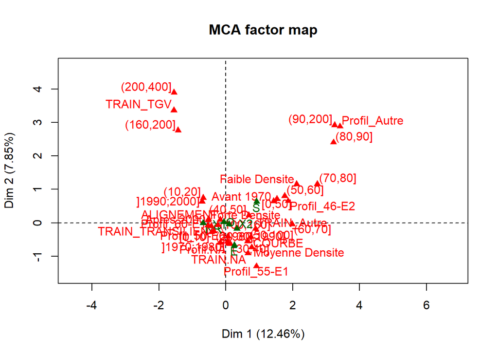

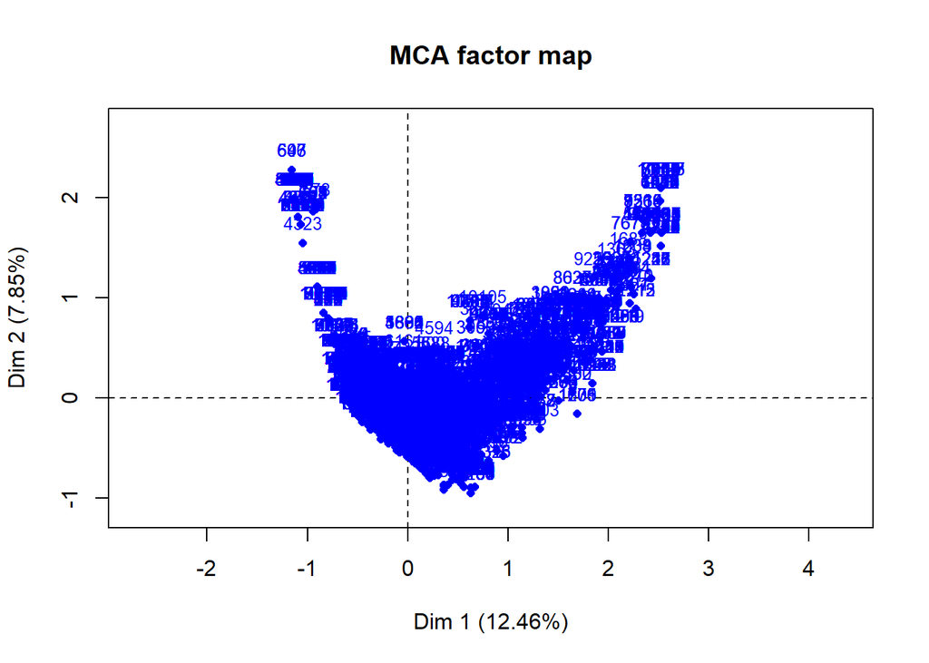

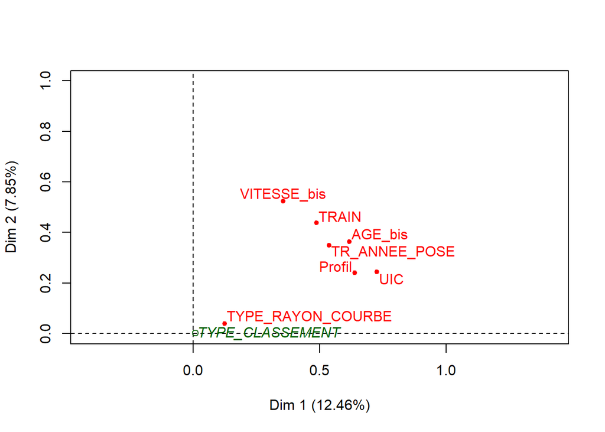

```r
summary(mca,ncp=2)
```

```
##
## Call:
## MCA(X = BASE_TRAVAIL_mca, quali.sup = 1)
##
##
## Eigenvalues
##                        Dim.1   Dim.2   Dim.3   Dim.4   Dim.5   Dim.6
## Variance               0.499   0.314   0.288   0.251   0.239   0.221
## % of var.             12.463   7.849   7.194   6.270   5.971   5.518
## Cumulative % of var.  12.463  20.311  27.506  33.776  39.747  45.265
##                        Dim.7   Dim.8   Dim.9  Dim.10  Dim.11  Dim.12
## Variance               0.174   0.157   0.156   0.147   0.144   0.144
## % of var.              4.349   3.928   3.908   3.666   3.608   3.589
## Cumulative % of var.  49.614  53.542  57.450  61.116  64.724  68.313
##                       Dim.13  Dim.14  Dim.15  Dim.16  Dim.17  Dim.18
## Variance               0.143   0.139   0.137   0.133   0.129   0.115
## % of var.              3.578   3.469   3.418   3.314   3.225   2.872
## Cumulative % of var.  71.890  75.359  78.777  82.091  85.316  88.189
##                       Dim.19  Dim.20  Dim.21  Dim.22  Dim.23  Dim.24
## Variance               0.099   0.076   0.066   0.054   0.051   0.035
## % of var.              2.476   1.893   1.656   1.361   1.280   0.877
## Cumulative % of var.  90.665  92.558  94.214  95.574  96.855  97.732
##                       Dim.25  Dim.26  Dim.27  Dim.28
## Variance               0.030   0.026   0.019   0.015
## % of var.              0.762   0.642   0.478   0.387
## Cumulative % of var.  98.493  99.135  99.613 100.000
##
## Individuals (the 10 first)
##                Dim.1    ctr   cos2    Dim.2    ctr   cos2
## 1           |  0.263  0.001  0.001 | -0.769  0.016  0.009 |
## 2           |  0.077  0.000  0.000 | -0.638  0.011  0.006 |
## 3           |  0.077  0.000  0.000 | -0.638  0.011  0.006 |
## 4           |  0.077  0.000  0.000 | -0.638  0.011  0.006 |
## 5           |  0.146  0.000  0.000 | -0.637  0.011  0.006 |
## 6           | -0.217  0.001  0.021 |  0.054  0.000  0.001 |
## 7           |  0.942  0.015  0.163 | -0.126  0.000  0.003 |
## 8           |  0.169  0.000  0.011 | -0.099  0.000  0.004 |
## 9           |  0.345  0.002  0.022 |  0.223  0.001  0.009 |
## 10          | -0.120  0.000  0.007 | -0.436  0.005  0.098 |
##
```

[output cut: 31 more lines]

```
## Profil            | 0.640 0.240 |
## TRAIN             | 0.488 0.439 |
##
## Supplementary categories
##                Dim.1   cos2 v.test    Dim.2   cos2 v.test
## E           |  0.256  0.000  0.362 | -0.666  0.000 -0.942 |
## NR          | -0.678  0.000 -0.678 | -0.005  0.000 -0.005 |
## O           | -0.060  0.007 -9.256 |  0.027  0.001  4.161 |
## S           |  0.922  0.000  1.304 |  0.633  0.000  0.895 |
## X1          |  0.096  0.004  6.752 | -0.040  0.001 -2.825 |
## X2          |  0.332  0.004  6.852 | -0.176  0.001 -3.639 |
##
## Supplementary categorical variables (eta2)
##                   Dim.1 Dim.2
## TYPE_CLASSEMENT | 0.009 0.002 |
```

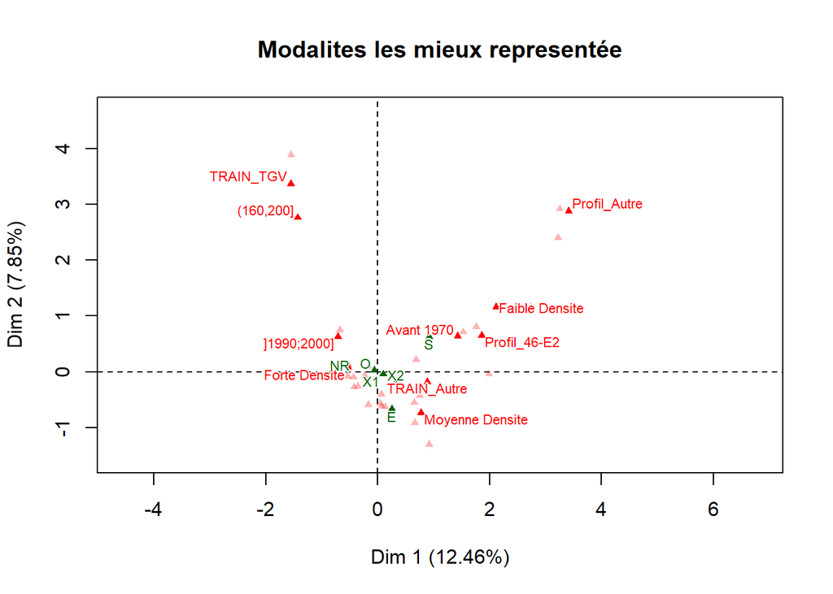

```r
plot(mca,shadow=TRUE,invisible=c("ind"),cex=0.7,title="Modalites les mieux representée",selectMod="cos2 10")
```

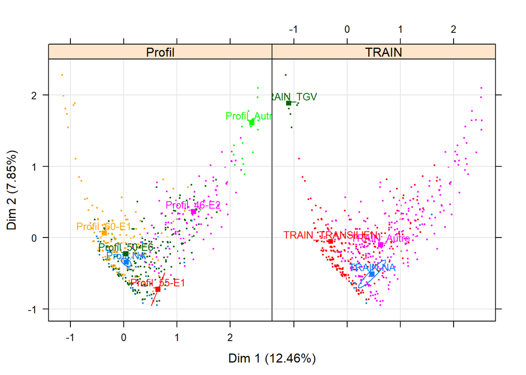

```r
plotellipses(mca,keepvar=c("TRAIN","Profil"),cex=0.8)
```

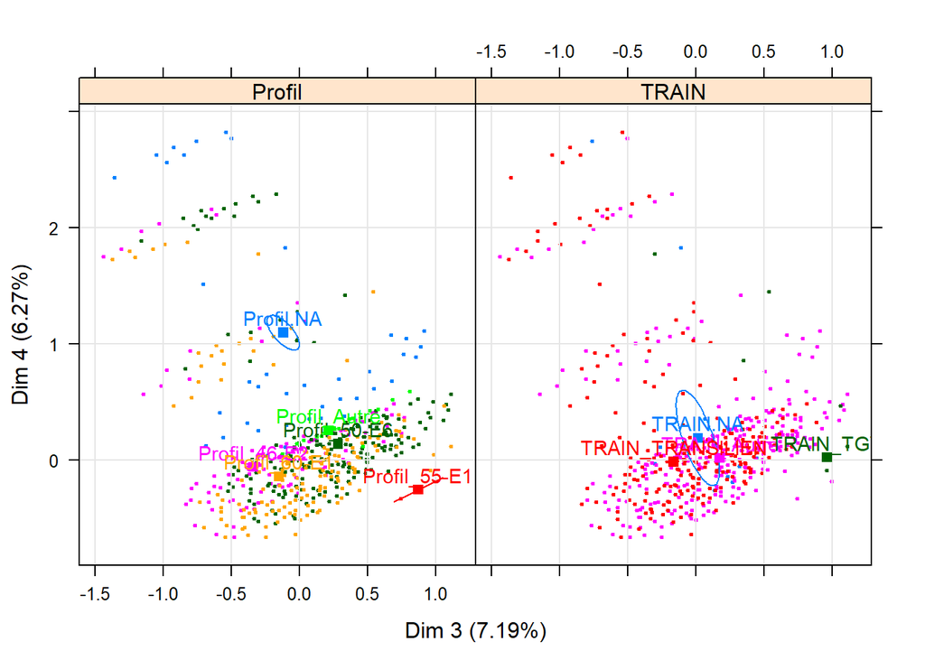

```r
plotellipses(mca,keepvar=c("TRAIN","Profil"),cex=0.9, axes=3:4)
```

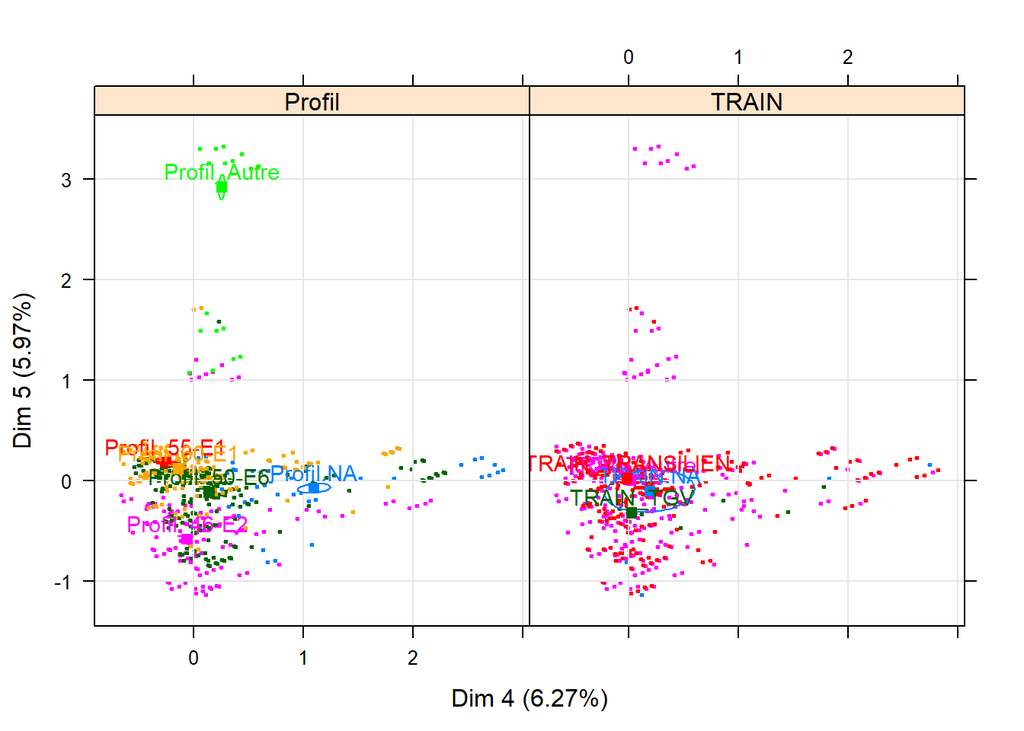

```r
plotellipses(mca,keepvar=c("TRAIN","Profil"),cex=0.9, axes=4:5)
```

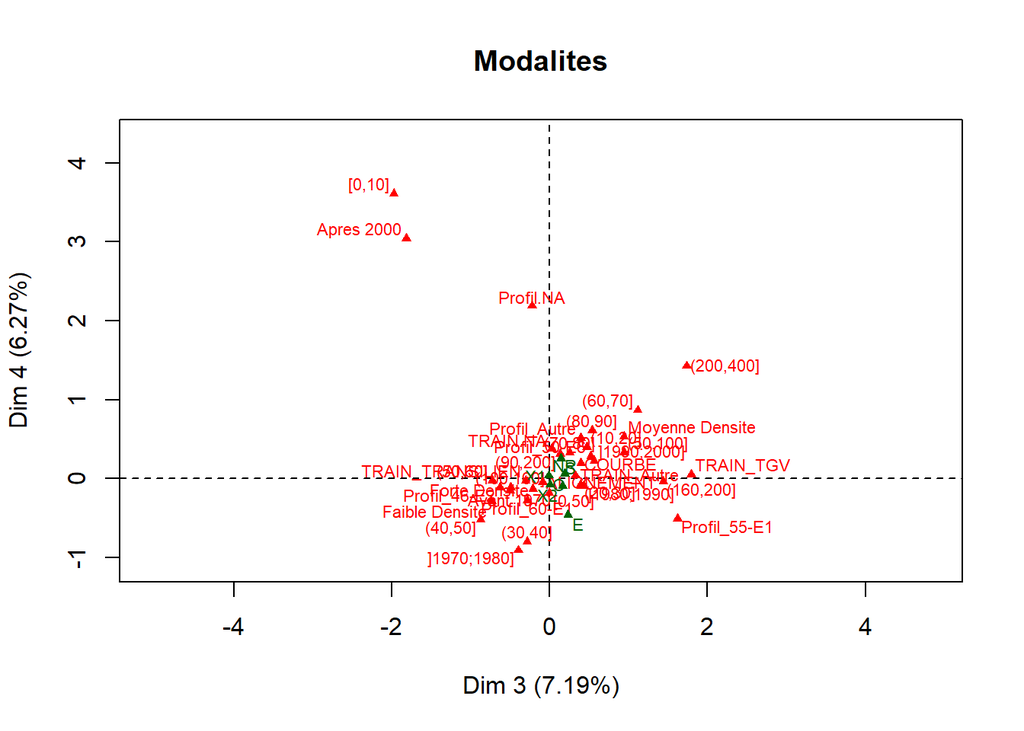

```r
plot(mca,invisible=c("ind"),cex=0.7,title="Modalites", axes=3:4)
```

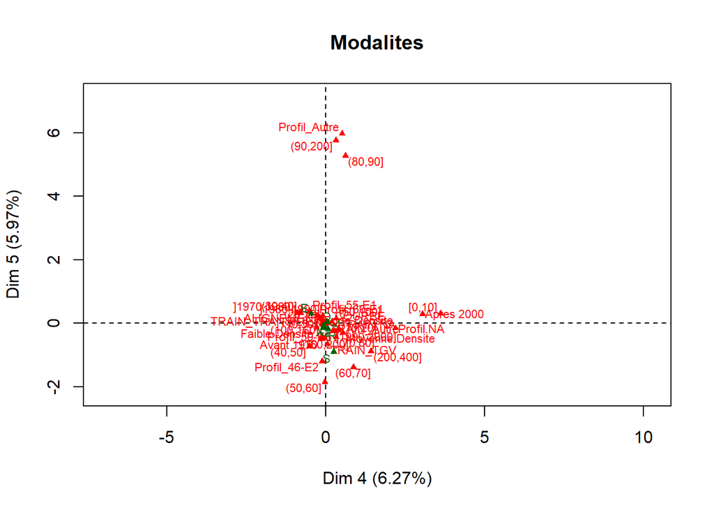

```r
plot(mca,invisible=c("ind"),cex=0.7,title="Modalites", axes=4:5)
```

# 4. Analyse factorielle AFM

```r
names(BASE_TRAVAIL)
```

```
##  [1] "ID_DEFAUT"         "LIGNE"             "VOIE_bis"
##  [4] "METRE"             "Profil"            "VITESSE"
##  [7] "TYPE_CLASSEMENT"   "EMPLACEMENT"       "AGE"
## [10] "RANG"              "AGE_bis"           "VITESSE_bis"
## [13] "TYPE_RAYON_COURBE" "TRAIN"             "UIC"
## [16] "Class_Binaire"     "ANNEE_POSE"        "TR_ANNEE_POSE"
```

La base pour l’analyse factorielle :

```r
BASE_TRAVAIL_afm <- subset(BASE_TRAVAIL, select=c(TYPE_CLASSEMENT, ANNEE_POSE, AGE, VITESSE, UIC, Profil, TRAIN,TYPE_RAYON_COURBE))
names(BASE_TRAVAIL_afm)
```

```
## [1] "TYPE_CLASSEMENT"   "ANNEE_POSE"        "AGE"
## [4] "VITESSE"           "UIC"               "Profil"
## [7] "TRAIN"             "TYPE_RAYON_COURBE"
```

Analyse factorielle avec TYPE_CLASSEMENT en supplementaire :

```r
#install.packages("FactoMineR")
library(FactoMineR)
afm<-MFA(BASE_TRAVAIL_afm, group=c(1,2,1,4), type=c("n",rep("s",2),"n"), num.group.sup=1, name.group=c("Classement","anciennete","vitesse","car.technique"))
```

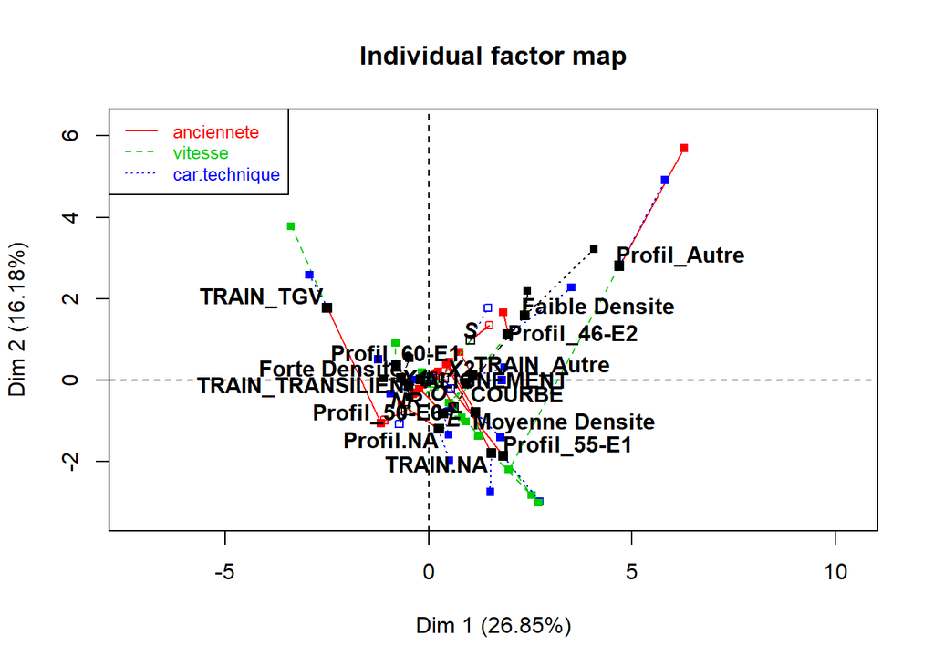

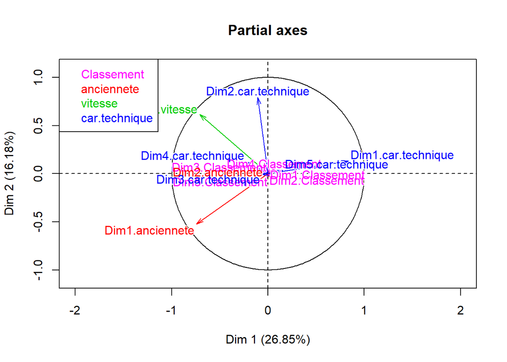

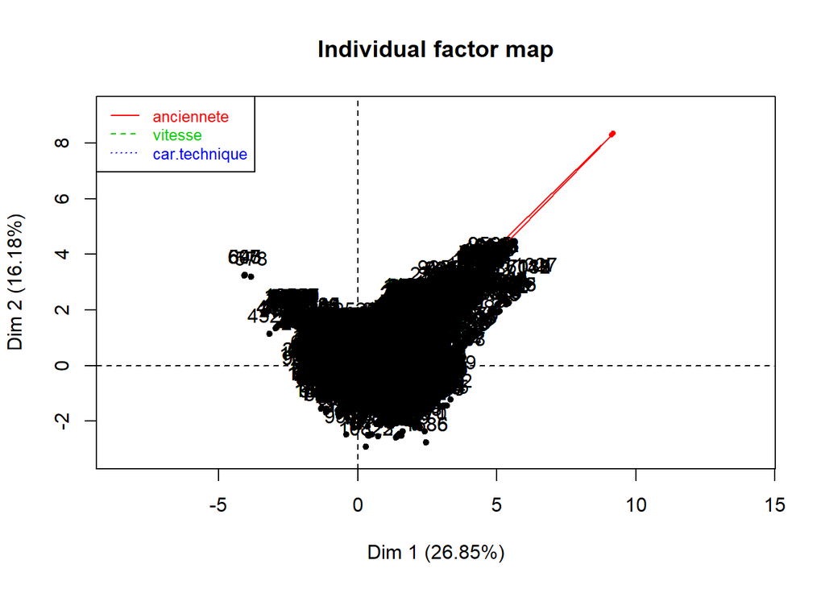

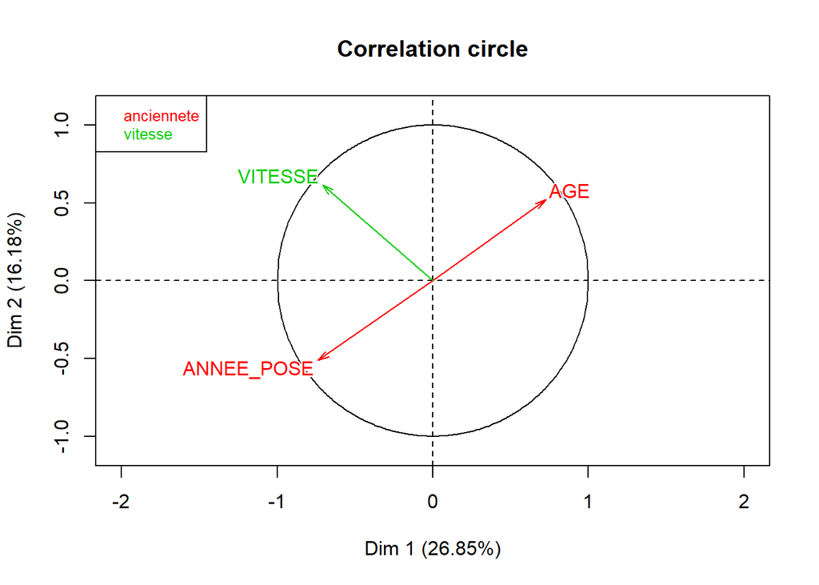

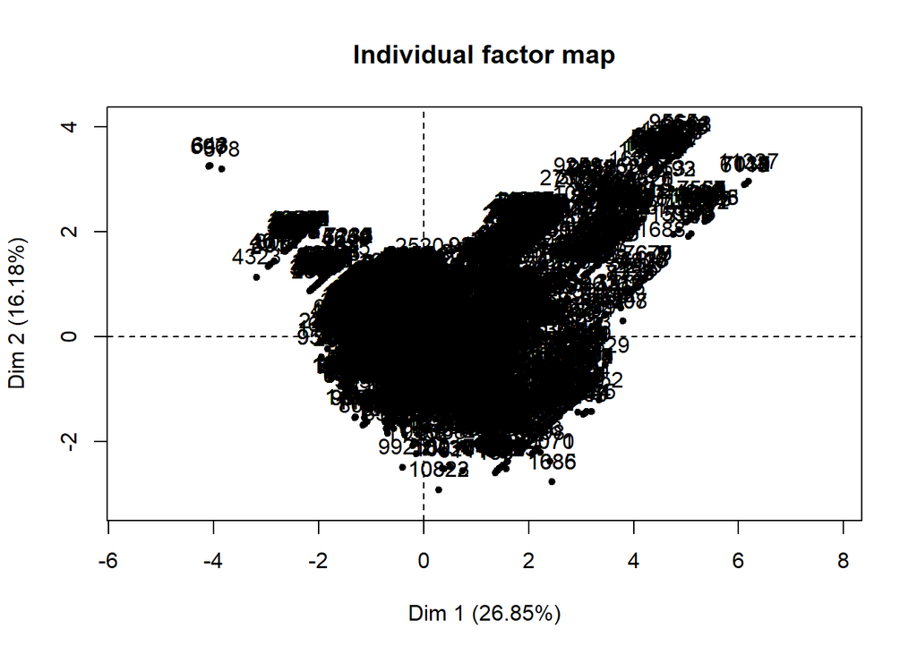

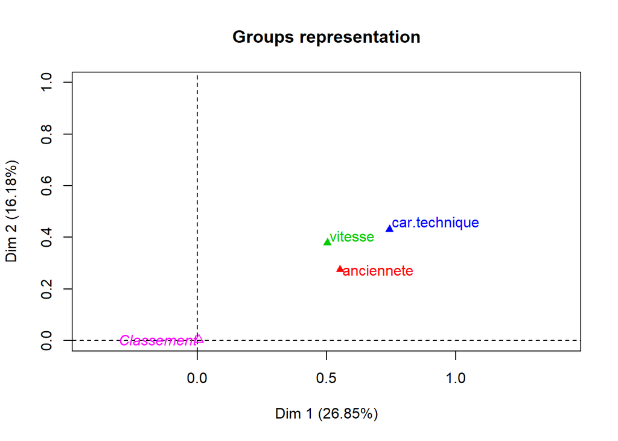

```r
summary(afm)
```

```
##
## Call:
## MFA(base = BASE_TRAVAIL_afm, group = c(1, 2, 1, 4), type = c("n",
##      rep("s", 2), "n"), name.group = c("Classement", "anciennete",
##      "vitesse", "car.technique"), num.group.sup = 1)
##
##
## Eigenvalues
##                        Dim.1   Dim.2   Dim.3   Dim.4   Dim.5   Dim.6
## Variance               1.799   1.084   0.583   0.451   0.443   0.424
## % of var.             26.853  16.177   8.698   6.738   6.613   6.335
## Cumulative % of var.  26.853  43.030  51.728  58.465  65.078  71.413
##                        Dim.7   Dim.8   Dim.9  Dim.10  Dim.11  Dim.12
## Variance               0.407   0.365   0.343   0.278   0.249   0.171
## % of var.              6.069   5.450   5.121   4.149   3.720   2.558
## Cumulative % of var.  77.482  82.933  88.053  92.202  95.922  98.480
##                       Dim.13  Dim.14  Dim.15  Dim.16  Dim.17  Dim.18
## Variance               0.075   0.027   0.000   0.000   0.000   0.000
## % of var.              1.114   0.406   0.000   0.000   0.000   0.000
## Cumulative % of var.  99.594 100.000 100.000 100.000 100.000 100.000
##
## Groups
##                    Dim.1    ctr   cos2    Dim.2    ctr   cos2    Dim.3
## anciennete      |  0.552 30.700  0.305 |  0.275 25.341  0.075 |  0.074
## vitesse         |  0.503 27.977  0.253 |  0.379 34.983  0.144 |  0.025
## car.technique   |  0.743 41.323  0.216 |  0.430 39.675  0.072 |  0.484
##                    ctr   cos2
## anciennete      12.642  0.005 |
## vitesse          4.236  0.001 |
## car.technique   83.121  0.092 |
##
## Supplementary group
##                   Dim.1  cos2   Dim.2  cos2   Dim.3  cos2
## Classement      | 0.005 0.000 | 0.003 0.000 | 0.005 0.000 |
##
## Individuals (the 10 first)
##                    Dim.1    ctr   cos2    Dim.2    ctr   cos2    Dim.3
## 1               |  1.276  0.008  0.008 | -1.904  0.028  0.018 | -0.312
## 2               |  1.083  0.006  0.006 | -1.800  0.025  0.017 | -1.008
## 3               |  1.101  0.006  0.006 | -1.783  0.025  0.016 | -1.021
```

[output cut: 53 more lines]

```
## Supplementary categories
##                    Dim.1   cos2 v.test    Dim.2   cos2 v.test    Dim.3
## E               |  0.618  0.306  0.652 | -0.669  0.359 -0.909 |  0.090
## NR              | -0.557  0.181 -0.415 | -0.741  0.320 -0.712 | -0.319
## O               | -0.057  0.245 -6.513 | -0.039  0.116 -5.765 | -0.035
## S               |  1.031  0.353  1.087 |  0.988  0.324  1.342 |  0.410
## X1              |  0.083  0.167  4.375 |  0.083  0.164  5.584 |  0.060
## X2              |  0.371  0.487  5.711 |  0.046  0.007  0.902 |  0.160
##                   cos2 v.test
## E                0.007  0.167 |
## NR               0.059 -0.417 |
## O                0.094 -7.069 |
## S                0.056  0.760 |
## X1               0.086  5.526 |
## X2               0.091  4.334 |
```

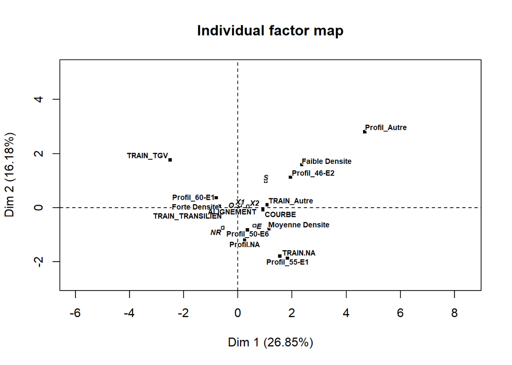

```r
plot(afm,invisible="ind",shadow=TRUE,cex=0.6)
```

```r
dimdesc(afm)
```

```
## $Dim.1
## $Dim.1$quanti
##            correlation p.value
## AGE          0.7271281       0
## VITESSE     -0.7094700       0
## ANNEE_POSE  -0.7379042       0
##
## $Dim.1$quali
##                            R2       p.value
## UIC               0.616216621  0.000000e+00
## Profil            0.587365934  0.000000e+00
## TRAIN             0.443339833  0.000000e+00
## TYPE_RAYON_COURBE 0.104018688 2.134020e-282
## TYPE_CLASSEMENT   0.005177569  7.789305e-12
##
## $Dim.1$category
##                    Estimate       p.value
## TRAIN_Autre       1.1683188  0.000000e+00
## Profil_Autre      3.3071281  0.000000e+00
## Profil_46-E2      0.5663400  0.000000e+00
## Moyenne Densite   0.2058586  0.000000e+00
## Faible Densite    1.4154576  0.000000e+00
## COURBE            0.5632927 2.134020e-282
## TRAIN.NA          1.6377190  3.850923e-09
## X2                0.1227869  1.097924e-08
## Profil_55-E1      0.4535163  6.287378e-03
## Profil.NA        -1.1287424  1.023486e-02
## X1               -0.1649570  1.204553e-05
## O                -0.3052194  7.122515e-11
## Profil_50-E6     -1.0208585 8.420310e-115
## ALIGNEMENT       -0.5632927 2.134020e-282
## TRAIN_TRANSILIEN -0.4013426  0.000000e+00
## TRAIN_TGV        -2.4046952  0.000000e+00
## Profil_60-E1     -2.1773835  0.000000e+00
## Forte Densite    -1.6213162  0.000000e+00
##
##
## $Dim.2
## $Dim.2$quanti
##            correlation p.value
```

[output cut: 51 more lines]

```
## TRAIN_Autre       0.263651115  0.000000e+00
## Profil_46-E2      1.227167924  0.000000e+00
## Moyenne Densite   0.189839169 4.875188e-292
## TRAIN_TGV         0.964098537 1.405831e-234
## Faible Densite    0.315766436 5.970628e-158
## Profil.NA         0.555806978  1.941767e-17
## X2                0.099120995  1.451322e-05
## TRAIN.NA         -0.708624101  4.544859e-04
## X1               -0.001216469  3.213283e-08
## O                -0.096299592  1.485036e-12
## Profil_60-E1     -0.067638324 1.678733e-105
## ALIGNEMENT       -0.445772260  0.000000e+00
## TRAIN_TRANSILIEN -0.519125551  0.000000e+00
## Profil_Autre     -2.535821093  0.000000e+00
## Forte Densite    -0.505605605  0.000000e+00
```

# 5. Gestion des NA sur Profil et TRAIN suite à Anafac :

Le premier plan de l’ACM represente 20% de l’info, ce qui est peu pour conclure. Le premier plan de l’AFM represente 43% de l’info, ce qui est mieux pour l’interpretation.

On voit que, dans les deux cas, et même en regardant les axes 3 et 4 : - La modalité NA de la variable Profil est proche de la modalité “50-E6” - La modalité NA de la variable TRAIN est proche de la modalité “Autre”

Nous remplaçons donc ces NA :

```r
# TRAIN
table(BASE_TRAVAIL$TRAIN, useNA="always")  # 26 NA
```

```
##
##      Autre        TGV TRANSILIEN       <NA>
##       4204        435       7078         26
```

```r
BASE_TRAVAIL$TRAIN <- as.character( BASE_TRAVAIL$TRAIN)
str(BASE_TRAVAIL)
```

```
## 'data.frame':    11743 obs. of  18 variables:
##  $ ID_DEFAUT        : int  14378 14491 14610 14839 14898 310270 310275 310280 310281 310301 ...
##  $ LIGNE            : int  990000 990000 990000 990000 990000 272000 1306 272000 272000 272000 ...
##  $ VOIE_bis         : Factor w/ 111 levels "10","11","12",..: 71 65 65 65 65 92 64 6 53 84 ...
##  $ METRE            : int  61421 60180 61280 61180 61575 1190 300 260 2200 2040 ...
##  $ Profil           : Factor w/ 5 levels "46-E2","50-E6",..: 2 2 2 2 4 4 2 2 2 4 ...
##  $ VITESSE          : int  70 70 70 70 70 60 30 60 30 90 ...
##  $ TYPE_CLASSEMENT  : Factor w/ 6 levels "E","NR","O","S",..: 3 3 3 5 5 3 3 3 3 3 ...
##  $ EMPLACEMENT      : Factor w/ 3 levels "","Ciel ouvert",..: 2 2 2 2 2 2 2 2 2 2 ...
##  $ AGE              : int  27 29 30 29 30 14 37 14 15 22 ...
##  $ RANG             : int  2 2 2 2 2 1 2 1 1 1 ...
##  $ AGE_bis          : Factor w/ 10 levels "[0,10]","(10,20]",..: 3 3 3 3 3 2 4 2 2 3 ...
##  $ VITESSE_bis      : Factor w/ 5 levels "[0,50]","(50,100]",..: 2 2 2 2 2 2 1 2 1 2 ...
##  $ TYPE_RAYON_COURBE: Factor w/ 2 levels "ALIGNEMENT","COURBE": 2 1 1 1 2 1 1 1 1 2 ...
##  $ TRAIN            : chr  NA NA NA NA ...
##  $ UIC              : Factor w/ 3 levels "Faible Densite",..: 3 3 3 3 3 2 2 2 2 3 ...
##  $ Class_Binaire    : int  0 0 0 1 1 0 0 0 0 0 ...
##  $ ANNEE_POSE       : int  1979 1977 1977 1977 1977 1993 1963 1993 1993 1981 ...
##  $ TR_ANNEE_POSE    : Factor w/ 5 levels "Avant 1970","]1970;1980]",..: 2 2 2 2 2 4 1 4 4 3 ...
```

```r
BASE_TRAVAIL$TRAIN[is.na(BASE_TRAVAIL$TRAIN)]   <- "Autre"
table(BASE_TRAVAIL$TRAIN, useNA="always")
```

```
##
##      Autre        TGV TRANSILIEN       <NA>
##       4230        435       7078          0
```

```r
BASE_TRAVAIL$TRAIN<-factor(BASE_TRAVAIL$TRAIN)
str(BASE_TRAVAIL)
```

```
## 'data.frame':    11743 obs. of  18 variables:
##  $ ID_DEFAUT        : int  14378 14491 14610 14839 14898 310270 310275 310280 310281 310301 ...
##  $ LIGNE            : int  990000 990000 990000 990000 990000 272000 1306 272000 272000 272000 ...
##  $ VOIE_bis         : Factor w/ 111 levels "10","11","12",..: 71 65 65 65 65 92 64 6 53 84 ...
##  $ METRE            : int  61421 60180 61280 61180 61575 1190 300 260 2200 2040 ...
##  $ Profil           : Factor w/ 5 levels "46-E2","50-E6",..: 2 2 2 2 4 4 2 2 2 4 ...
##  $ VITESSE          : int  70 70 70 70 70 60 30 60 30 90 ...
##  $ TYPE_CLASSEMENT  : Factor w/ 6 levels "E","NR","O","S",..: 3 3 3 5 5 3 3 3 3 3 ...
##  $ EMPLACEMENT      : Factor w/ 3 levels "","Ciel ouvert",..: 2 2 2 2 2 2 2 2 2 2 ...
##  $ AGE              : int  27 29 30 29 30 14 37 14 15 22 ...
##  $ RANG             : int  2 2 2 2 2 1 2 1 1 1 ...
##  $ AGE_bis          : Factor w/ 10 levels "[0,10]","(10,20]",..: 3 3 3 3 3 2 4 2 2 3 ...
##  $ VITESSE_bis      : Factor w/ 5 levels "[0,50]","(50,100]",..: 2 2 2 2 2 2 1 2 1 2 ...
##  $ TYPE_RAYON_COURBE: Factor w/ 2 levels "ALIGNEMENT","COURBE": 2 1 1 1 2 1 1 1 1 2 ...
##  $ TRAIN            : Factor w/ 3 levels "Autre","TGV",..: 1 1 1 1 1 3 1 1 1 3 ...
##  $ UIC              : Factor w/ 3 levels "Faible Densite",..: 3 3 3 3 3 2 2 2 2 3 ...
##  $ Class_Binaire    : int  0 0 0 1 1 0 0 0 0 0 ...
##  $ ANNEE_POSE       : int  1979 1977 1977 1977 1977 1993 1963 1993 1993 1981 ...
##  $ TR_ANNEE_POSE    : Factor w/ 5 levels "Avant 1970","]1970;1980]",..: 2 2 2 2 2 4 1 4 4 3 ...
```

```r
# Profil
table(BASE_TRAVAIL$Profil, useNA="always") # 187 NA
```

```
##
## 46-E2 50-E6 55-E1 60-E1 Autre  <NA>
##  1121  4438     4  5817   176   187
```

```r
BASE_TRAVAIL$Profil <- as.character( BASE_TRAVAIL$Profil)
str(BASE_TRAVAIL)
```

```
## 'data.frame':    11743 obs. of  18 variables:
##  $ ID_DEFAUT        : int  14378 14491 14610 14839 14898 310270 310275 310280 310281 310301 ...
##  $ LIGNE            : int  990000 990000 990000 990000 990000 272000 1306 272000 272000 272000 ...
##  $ VOIE_bis         : Factor w/ 111 levels "10","11","12",..: 71 65 65 65 65 92 64 6 53 84 ...
##  $ METRE            : int  61421 60180 61280 61180 61575 1190 300 260 2200 2040 ...
##  $ Profil           : chr  "50-E6" "50-E6" "50-E6" "50-E6" ...
##  $ VITESSE          : int  70 70 70 70 70 60 30 60 30 90 ...
##  $ TYPE_CLASSEMENT  : Factor w/ 6 levels "E","NR","O","S",..: 3 3 3 5 5 3 3 3 3 3 ...
##  $ EMPLACEMENT      : Factor w/ 3 levels "","Ciel ouvert",..: 2 2 2 2 2 2 2 2 2 2 ...
##  $ AGE              : int  27 29 30 29 30 14 37 14 15 22 ...
##  $ RANG             : int  2 2 2 2 2 1 2 1 1 1 ...
##  $ AGE_bis          : Factor w/ 10 levels "[0,10]","(10,20]",..: 3 3 3 3 3 2 4 2 2 3 ...
##  $ VITESSE_bis      : Factor w/ 5 levels "[0,50]","(50,100]",..: 2 2 2 2 2 2 1 2 1 2 ...
##  $ TYPE_RAYON_COURBE: Factor w/ 2 levels "ALIGNEMENT","COURBE": 2 1 1 1 2 1 1 1 1 2 ...
##  $ TRAIN            : Factor w/ 3 levels "Autre","TGV",..: 1 1 1 1 1 3 1 1 1 3 ...
##  $ UIC              : Factor w/ 3 levels "Faible Densite",..: 3 3 3 3 3 2 2 2 2 3 ...
##  $ Class_Binaire    : int  0 0 0 1 1 0 0 0 0 0 ...
##  $ ANNEE_POSE       : int  1979 1977 1977 1977 1977 1993 1963 1993 1993 1981 ...
##  $ TR_ANNEE_POSE    : Factor w/ 5 levels "Avant 1970","]1970;1980]",..: 2 2 2 2 2 4 1 4 4 3 ...
```

```r
BASE_TRAVAIL$Profil[is.na(BASE_TRAVAIL$Profil)]   <- "50-E6"
table(BASE_TRAVAIL$Profil, useNA="always")
```

```
##
## 46-E2 50-E6 55-E1 60-E1 Autre  <NA>
##  1121  4625     4  5817   176     0
```

```r
BASE_TRAVAIL$Profil<-factor(BASE_TRAVAIL$Profil)
str(BASE_TRAVAIL)
```

```
## 'data.frame':    11743 obs. of  18 variables:
##  $ ID_DEFAUT        : int  14378 14491 14610 14839 14898 310270 310275 310280 310281 310301 ...
##  $ LIGNE            : int  990000 990000 990000 990000 990000 272000 1306 272000 272000 272000 ...
##  $ VOIE_bis         : Factor w/ 111 levels "10","11","12",..: 71 65 65 65 65 92 64 6 53 84 ...
##  $ METRE            : int  61421 60180 61280 61180 61575 1190 300 260 2200 2040 ...
##  $ Profil           : Factor w/ 5 levels "46-E2","50-E6",..: 2 2 2 2 4 4 2 2 2 4 ...
##  $ VITESSE          : int  70 70 70 70 70 60 30 60 30 90 ...
##  $ TYPE_CLASSEMENT  : Factor w/ 6 levels "E","NR","O","S",..: 3 3 3 5 5 3 3 3 3 3 ...
##  $ EMPLACEMENT      : Factor w/ 3 levels "","Ciel ouvert",..: 2 2 2 2 2 2 2 2 2 2 ...
##  $ AGE              : int  27 29 30 29 30 14 37 14 15 22 ...
##  $ RANG             : int  2 2 2 2 2 1 2 1 1 1 ...
##  $ AGE_bis          : Factor w/ 10 levels "[0,10]","(10,20]",..: 3 3 3 3 3 2 4 2 2 3 ...
##  $ VITESSE_bis      : Factor w/ 5 levels "[0,50]","(50,100]",..: 2 2 2 2 2 2 1 2 1 2 ...
##  $ TYPE_RAYON_COURBE: Factor w/ 2 levels "ALIGNEMENT","COURBE": 2 1 1 1 2 1 1 1 1 2 ...
##  $ TRAIN            : Factor w/ 3 levels "Autre","TGV",..: 1 1 1 1 1 3 1 1 1 3 ...
##  $ UIC              : Factor w/ 3 levels "Faible Densite",..: 3 3 3 3 3 2 2 2 2 3 ...
##  $ Class_Binaire    : int  0 0 0 1 1 0 0 0 0 0 ...
##  $ ANNEE_POSE       : int  1979 1977 1977 1977 1977 1993 1963 1993 1993 1981 ...
##  $ TR_ANNEE_POSE    : Factor w/ 5 levels "Avant 1970","]1970;1980]",..: 2 2 2 2 2 4 1 4 4 3 ...
```

# 6. Base de travail totale / de Construction / de Test :

```r
table(BASE_TRAVAIL$TYPE_CLASSEMENT, useNA="always")
```

```
##
##    E   NR    O    S   X1   X2 <NA>
##    2    1 7848    2 3479  411    0
```

```r
set.seed(1444) # on fixe la graine aléatoire pour la reproductibilité
train <- sample(1:nrow(BASE_TRAVAIL),2*nrow(BASE_TRAVAIL)/3) # on selectionne 2/3 des lignes
test  <- (-train)
BASE_TRAVAIL_TRAIN <- BASE_TRAVAIL[train,]
BASE_TRAVAIL_TEST  <- BASE_TRAVAIL[test,]

table(BASE_TRAVAIL$TYPE_CLASSEMENT, useNA="always")
```

```
##
##    E   NR    O    S   X1   X2 <NA>
##    2    1 7848    2 3479  411    0
```

```r
table(BASE_TRAVAIL_TRAIN$TYPE_CLASSEMENT, useNA="always")
```

```
##
##    E   NR    O    S   X1   X2 <NA>
##    1    1 5256    1 2296  273    0
```

```r
table(BASE_TRAVAIL_TEST$TYPE_CLASSEMENT, useNA="always")
```

```
##
##    E   NR    O    S   X1   X2 <NA>
##    1    0 2592    1 1183  138    0
```

```r
round(prop.table(table(BASE_TRAVAIL$TYPE_CLASSEMENT))*100,digits=2)
```

```
##
##     E    NR     O     S    X1    X2
##  0.02  0.01 66.83  0.02 29.63  3.50
```

```r
round(prop.table(table(BASE_TRAVAIL_TRAIN$TYPE_CLASSEMENT))*100,digits=2)
```

```
##
##     E    NR     O     S    X1    X2
##  0.01  0.01 67.14  0.01 29.33  3.49
```

```r
round(prop.table(table(BASE_TRAVAIL_TEST$TYPE_CLASSEMENT))*100,digits=2)
```

```
##
##     E    NR     O     S    X1    X2
##  0.03  0.00 66.21  0.03 30.22  3.52
```

```r
write.csv2(BASE_TRAVAIL, file="BASE_TRAVAIL.csv")
write.csv2(BASE_TRAVAIL_TRAIN, file="BASE_TRAVAIL_TRAIN.csv")
write.csv2(BASE_TRAVAIL_TEST, file="BASE_TRAVAIL_TEST.csv")
```

Les variables pour la modélisation :

TYPE_CLASSEMENT Class_Binaire TYPE_RAYON_COURBE ANNEE_POSE TR_ANNEE_POSE AGE_bis AGE VITESSE_bis VITESSE UIC TRAIN Profil